# Analyses of long-term trends in apparent survival of Snowfinches

Fränzi Korner-Nievergelt

2023-07-13

# 1 Questions

How did apparent annual survival change over the years in males and females? How does apparent annual survival correlate with summer and winter temperature?

```r
library(R2jags)
#install.packages("RNCEP", dependencies = TRUE)
library(RNCEP)
library(knitr)
```

# 2 Data

## 2.1 Mark-recapture data

```r
#dat <- read.table("aichhorn.txt", header=TRUE, sep="\t")
dat <- read.table("data/Ringliste_1966-2021AmbrosJohn_korr.txt", header=TRUE, sep="\t")


#table(dat$year, dat$month)
#dat[dat$year=="year",]
dat <- dat[dat$year!="year",] # l?sche Zeile, wo nochmals die Spalten?berschriften drin sind

# l?sche Zeilen ohne Monat und Jahr
dat <- dat[dat$year!="",]
dat <- dat[dat$month!="",]
dat <- dat[!is.na(dat$year),]
```

## 2.2 Temperature data

```r
range(dat$year)
wdtemp <- NCEP.gather("air.sig995", level="surface", months.minmax=c(4,5), years.minmax=c(1964, 2004),
    lat.southnorth=c(46.5,47.5), lon.westeast=c(10,13), reanalysis2 = FALSE,
    return.units = TRUE, status.bar=TRUE)
#[1] Units of variable 'air.sig995' are degK

str(wdtemp)
dim(wdtemp)
tempph <- apply(wdtemp, 3, mean)

# turn Kelvin into Celsius
tempphC <- tempph-273.15
hist(tempphC)
yearwd <- substring(dimnames(wdtemp)[[3]], 1, 4)
dtemp <- data.frame(temp=tempphC, year=yearwd)
wdat <- aggregate(temp~year, data=dtemp, FUN=mean)
wdat$year <- as.numeric(wdat$year)
names(wdat)[names(wdat)=="temp"] <- "temp45"
plot(wdat$year, wdat$temp45)
abline(lm(temp45~year, wdat))
#save(wdat, file="data/weather_data.rda")


# add sommer temp

wdtemp <- NCEP.gather("air.sig995", level="surface", months.minmax=c(6,8), years.minmax=c(1964, 2004),
    lat.southnorth=c(46.5,47.5), lon.westeast=c(10,13), reanalysis2 = FALSE,
    return.units = TRUE, status.bar=TRUE)

tempph <- apply(wdtemp, 3, mean)

# turn Kelvin into Celsius
tempphC <- tempph-273.15
hist(tempphC)
yearwd <- substring(dimnames(wdtemp)[[3]], 1, 4)
dtemp <- data.frame(temp=tempphC, year=yearwd)
wdat$temp68 <- aggregate(temp~year, data=dtemp, FUN=mean)$temp

plot(wdat$year, wdat$temp68)
abline(lm(temp68~year, wdat))
#save(wdat, file="data/weather_data.rda")

## add winter temp
wdtemp <- NCEP.gather("air.sig995", level="surface", months.minmax=c(1,3), years.minmax=c(1964, 2004),
    lat.southnorth=c(46.5,47.5), lon.westeast=c(10,13), reanalysis2 = FALSE,
    return.units = TRUE, status.bar=TRUE)

tempph <- apply(wdtemp, 3, mean)

# turn Kelvin into Celsius
tempphC <- tempph-273.15
hist(tempphC)
yearwd <- substring(dimnames(wdtemp)[[3]], 1, 4)
dtemp <- data.frame(temp=tempphC, year=yearwd)
wdat$temp13 <- aggregate(temp~year, data=dtemp, FUN=mean)$temp

plot(wdat$year, wdat$temp13)
abline(lm(temp13~year, wdat))


# sommer temperature
wdtemp <- NCEP.gather("air.sig995", level="surface", months.minmax=c(5,8), years.minmax=c(1964, 2004),
    lat.southnorth=c(46.5,47.5), lon.westeast=c(10,13), reanalysis2 = FALSE,
    return.units = TRUE, status.bar=TRUE)

tempph <- apply(wdtemp, 3, mean)

# turn Kelvin into Celsius
tempphC <- tempph-273.15
hist(tempphC)
yearwd <- substring(dimnames(wdtemp)[[3]], 1, 4)
dtemp <- data.frame(temp=tempphC, year=yearwd)
wdat$temp58 <- aggregate(temp~year, data=dtemp, FUN=mean)$temp


#save(wdat, file="data/weather_data.rda")

# if we would like to add precipitation:
#wdprec <- NCEP.gather("pr_wtr.eatm", level="surface")
```

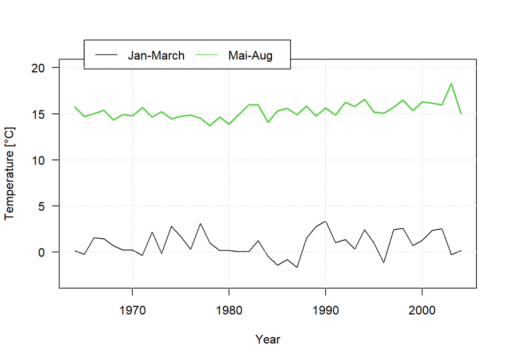

```r
load("data/weather_data.rda")
#pairs(wdat[,2:4])
plot(wdat$year, wdat$temp13, type="l", ylim=c(-3,20), las=1, ylab="Temperature [°C]",
     xlab="Year")
#lines(wdat$year, wdat$temp45, col=2)
#lines(wdat$year, wdat$temp68, col=3)
lines(wdat$year, wdat$temp58, col=3, lwd=2)
legend(1965, 23, lwd=c(1,1,1,2), col=c(1,3), legend=c("Jan-March", "Mai-Aug"), horiz=TRUE, xpd=NA)
grid()
```

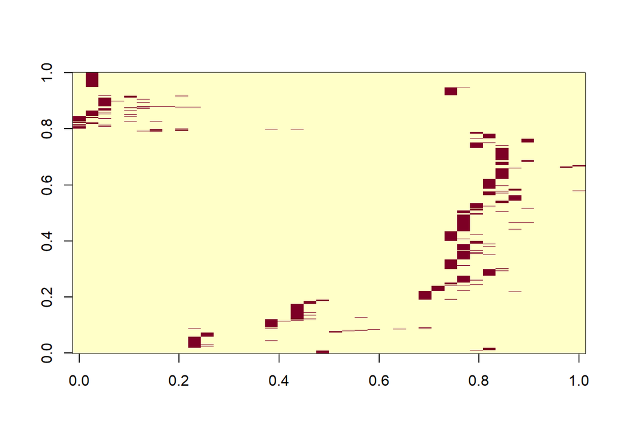

```r
# erstelle capture occasion
# Jahreswechsel findet im September statt, da keine Beringung
# Datenbeginn ab Okt 1964
# Ende sommer 2021, f?r die Ambros-Daten nur bis 2004 nehmen

tmonth <- rep(c(10,11,12,1:9), times=length(1965:2004))
tyear <- c(rep(1964, 3), rep(1965:2003, each=12), rep(2004, 9))
occpmonth <- rep(1:(length(tyear)/12), each=12)

# check: die 3 vectoren sollen alle die gleiche L?nge haben
docc <- data.frame(month=tmonth,
    year=tyear,
    occ = occpmonth)

# join weather data to docc
docc$temp45 <- wdat$temp45[match(docc$year, wdat$year)]
docc$temp68 <- wdat$temp68[match(docc$year, wdat$year)]
docc$temp13 <- wdat$temp13[match(docc$year, wdat$year)]
docc$temp58 <- wdat$temp58[match(docc$year, wdat$year)]

x.temp45 <- docc$temp45[docc$month==4]
x.temp68 <- docc$temp68[docc$month==6]
x.temp13 <- docc$temp13[docc$month==2]
x.temp58 <- docc$temp58[docc$month==2]

dat$occ <- occpmonth[match(paste(dat$month, dat$year), paste(tmonth, tyear))]
nocc <- max(occpmonth) # letzte Fangoccasion
dat$occ <- factor(dat$occ, levels=unique(occpmonth))
dat <- dat[!is.na(dat$occ),]

table(dat$Sex)
##
##         0    1    2
##  257   72 1004  403
table(tapply(dat$Sex, dat$ringnr, function(x) length(unique(x))))
##
##    1    2    3
## 1381  135    3


# Wir m?ssen alle wiederf?nge nehmen, nach der ersten Geschlechtsbestimmung
table(table(dat$ringnr)) # das sind viel mehr Wiederf?nge als 7!
##
##    1    2    3    4    5
## 1349  133   29    6    2

# f?lle die fehlenden Geschlechtsangaben nach der ersten Bestimmung auf:
dat$ringnr <- factor(dat$ringnr)
dat <- dat[order(dat$ringnr, dat$year, dat$month, dat$day),] # sortiere nach Ringnummer und Datum
nind <- nlevels(dat$ringnr)
for(i in 1:nind){
  index <- dat$ringnr==levels(dat$ringnr)[i]
  sexindatenfile <- dat$Sex[index]
  sexindatenfile
  if(length(sexindatenfile)>1){
    erstebestimmung <- c(1:sum(index))[is.element(sexindatenfile, c("1", "2"))][1]
    if(!is.na(erstebestimmung)) dat$Sex[index][erstebestimmung:sum(index)] <- sexindatenfile[erstebestimmung]
  }
}
table(dat$Sex)
##
##         0    1    2
##  106   70 1120  440
dat$Sex <- as.numeric(dat$Sex)
dat$Sex[dat$Sex==0] <- NA

#dat <- dat[dat$Sex>0,] # wir nehmen unbestimmte mit
# Geschlechterverh?ltnis in den Winterf?ngen
prop.table(table(dat$Sex[is.element(dat$month,c(10,11,12,1,2,3,4))]))
##
##        1        2
## 0.723822 0.276178
prop.table(table(dat$Sex[is.element(dat$month,c(5:9))]))
##
##      1      2
## 0.4375 0.5625

# werfe Sommerf?nge weg
dat <- dat[!is.element(dat$month, c(5:9)),]

year.z <- as.numeric(scale(2:nocc))


# F?ge Reihenfolge der Wiederf?nge ein
dat$ringnr <- factor(dat$ringnr)
nind <- nlevels(dat$ringnr)
dat <- dat[order(dat$ringnr, dat$year, dat$month, dat$day),] # sortiere nach Ringnummer und Datum
sexpind <- numeric(nind)
for(i in 1:nlevels(dat$ringnr)){
  ringnri <- levels(dat$ringnr)[i]
  index <- dat$ringnr==ringnri
  dat$capturenr[index] <- 1:sum(index)
  sexpind[i] <- dat$Sex[index][1]
}

table(sexpind)
## sexpind
##   1   2
## 973 387

first <- as.numeric(as.character(dat$occ[dat$capturenr==1])) # Beringungsoccasion f?r jedes Individuum


ch <- table(dat$ringnr, dat$occ)
ch[ch>1] <- 1
image(t(ch))
```

# 3 Model

CJS-model

We intended to fit a model with three predictors for apparent survival: year, summer and winter temperature. However, this model did not converge because correlation between summer temperature and year was too high (r= 0.57`). Therefore, we fitted two models, one including year and winter temperature, and one including summer and winter temperature.

The further correct for among-year variance in capture probabilities by including a random year effect in the linear predictor for capture probability. Also, we corrected for different capture probabilities between the sexes.

We do not account for transients because fitting the model with a separate survival after first capture was not estimable and looking at the raw data does not suggest the presence of transients because the proportion of recaptured birds after the first and second capture is similarly around 9%.

We also tried to include a random year effect on survival. However, this model did not converge.

```r
npi <- apply(ch, 1, sum)
table(npi)
## npi
##    1    2    3
## 1339  121   10
121/1339
## [1] 0.09036594
10/121
## [1] 0.08264463
# about the same proportion re-captures after first and second -> no transients!

length(first) # L?nge ist Anzahl Individuen
## [1] 1470
dim(ch)  # Anzahl Zeile ist Anzahl Individuen, Azahl Spalten = Anzahl occasions
## [1] 1470   40
table(apply(ch, 1, sum)) # wie viele Individuen sind wie ofte gefangen worden
##
##    1    2    3
## 1339  121   10


indfirst <- matrix(0, nrow=nrow(ch), ncol=ncol(ch))
for(i in 1:nrow(indfirst)) indfirst[i, first[i]] <- 1
# Stelle Daten f?r jags zusammen
datax <- list(y=ch,
              first=first,
              nocc=nocc,
              nind=nrow(ch))  #indfirst=indfirst
dimnames(datax$y) <- NULL
#für inklpredictors
datax$sex <- sexpind
datax$year.z <- as.numeric(scale(1:nocc))
datax$temp58.z <- as.numeric(scale(x.temp58))
datax$temp13.z <- as.numeric(scale(x.temp13))


# Definiere initial values f?r die Markov-chains
last <- apply(datax$y, 1, function(x) max(c(1:nocc)[x==1]))
initz <- matrix(0, ncol=ncol(datax$y), nrow=nrow(datax$y))
for(i in 1:nrow(datax$y)) {
  initz[i, first[i]:last[i]] <- 1
  initz[i, 1:first[i]] <- NA
}

initfun <- function(){
  list(b0=runif(2,-0.5,0.5),
       b1=runif(2, -0.5,0.5),
      #b2=runif(2, -0.5,0.5),
      #b3=runif(2, -0.5,0.5),
      #b4=runif(2, -0.5,0.5),
       a0=runif(2,-0.5,0.5),
       z=initz,
      sigmapyear=runif(1,0.01,0.5))
}
```

```r
# Fitte das Modell in jags---------------------------------------------
# year effect alone, model without temperature
mod <- jags(datax, inits=initfun, parameters.to.save=c("a0", "b0", "b1", "sigmapyear", "propm", "pyeareff"),
            model.file="jags/cjs_bugs_aichhorn_wth_temp.txt",
            n.chains=3, n.iter=50000, n.thin = 5)  #n.thin=10
save(mod, file="model.aichhorn_230627.rda") # speichere das Modell
# -> high correlation between year and temp58-effect

# ohne Jahr:
mod <- jags(datax, inits=initfun, parameters.to.save=c("a0", "b0", "b2", "b3", "sigmapyear", "propm", "pyeareff"),
            model.file="jags/cjs_bugs_aichhorn_wth_year.txt",
            n.chains=3, n.iter=50000, n.thin = 5)  #n.thin=10
save(mod, file="model.aichhorn_wth_year_230627.rda") # speichere das Modell
# i fitted both models on the server... therefore the names do not match the names I read in below
```

```r
load("model.aichhorn_wth_year_230627.rda")
modtemp <- mod$BUGSoutput

load("model.aichhorn_wth_temp_230627.rda")
modyear <- mod$BUGSoutput
```

```r
# check convergence
library(blmeco)
historyplot(modohneJahr, "a0")
historyplot(modohneJahr, "b0")
historyplot(modohneJahr, "b2")
# Konvergenz ist noch nicht sehr gut...

pairs(cbind(modohneJahr$sims.list$a0, modohneJahr$sims.list$b0, modohneJahr$sims.list$b2, modohneJahr$sims.list$b3),
      labels=c(rep(c("a0", "b0", "b2", "b3"), each=2)))
```

# 4 Results

The model including year and winter temperature as predictors for apparent survival had a deviance (measure of unexplained variance) of 2517 and the model including summer temperature instead of year as predictor had a deviance of 2499. Thus the summer temperature could explain a slightly higher proportion of variance in apparent annual survival compared to year.

Average apparent survival (for an average year and average summer and winter temperatures) was around 10% higher in males compared to females. This estimate was similar in both models.

```r
# posterior distribution of annual apparent survival (given mean year and mean temperature)

# from the model with year and winter temperature
phi1 <- plogis(apply(modyear$sims.list$b0, 2,mean)) # apparent annual survival
phi1CI <- plogis(apply(modyear$sims.list$b0,2,quantile, probs=c(0.025, 0.975))) # 95% CI apparent annual survival

# from the model with sommer and winter temperature
phi2 <- plogis(apply(modtemp$sims.list$b0, 2,mean)) # apparent annual survival
phi2CI <- plogis(apply(modtemp$sims.list$b0,2,quantile, probs=c(0.025, 0.975))) # 95% CI

tab <- data.frame(phi1=phi1, phi1.lwr=phi1CI[1,], phi1.upr=phi1CI[2,],
                  phi2=phi2, phi2.lwr=phi2CI[1,], phi2.upr=phi2CI[2,])
rownames(tab) <- c("male", "female")
kable(tab, digits=2, caption="Average apparent annual survival probabilities from the two models (1) including year and winter temperature as predictors, and (2) including sommer and winter temperature as predictors.")
```

Table 4.1: Average apparent annual survival probabilities from the two models (1) including year and winter temperature as predictors, and (2) including sommer and winter temperature as predictors.

|  | phi1 | phi1.lwr | phi1.upr | phi2 | phi2.lwr | phi2.upr |
| --- | --- | --- | --- | --- | --- | --- |
| male | 0.65 | 0.58 | 0.73 | 0.62 | 0.55 | 0.68 |
| female | 0.55 | 0.40 | 0.74 | 0.53 | 0.39 | 0.66 |

The average capture probability of individuals that are alive in the study area was 0.05 for both sexes.

```r
p1 <- plogis(apply(modyear$sims.list$a0, 2,mean)) # Fangwahrscheinlichkeit
p1CI <- plogis(apply(modyear$sims.list$a0,2,quantile, probs=c(0.025, 0.975))) # 95% CI


p2 <- plogis(apply(modtemp$sims.list$a0, 2,mean)) # Fangwahrscheinlichkeit
p2CI <- plogis(apply(modtemp$sims.list$a0,2,quantile, probs=c(0.025, 0.975))) # 95% CI

tab <- data.frame(p1=p1, p1.lwr=p1CI[1,], p1.upr=p1CI[2,],
                  p2=p2, p2.lwr=p2CI[1,], p2.upr=p2CI[2,])
rownames(tab) <- c("male", "female")
kable(tab, digits=2, caption="Average capture probabilities from the two models (1) including year and winter temperature as predictors, and (2) including sommer and winter temperature as predictors.")
```

Table 4.2: Average capture probabilities from the two models (1) including year and winter temperature as predictors, and (2) including sommer and winter temperature as predictors.

[output not shown]

Apparent survival decreased over the years in females, but not so in males.

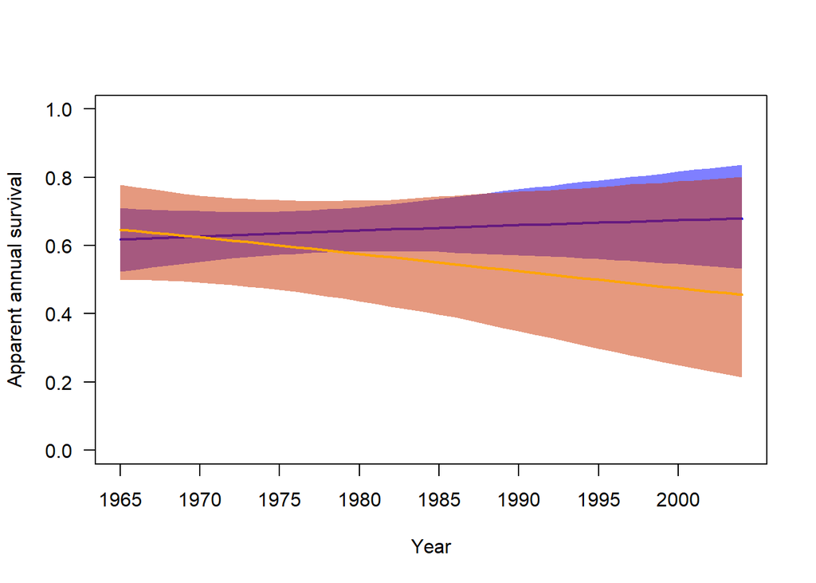

Figure 4.1: Trend in apparent annual survival of male (blue) and female (orange) Snowfinches. Shaded are is 95% credible interval.

```r
# Trend über die Jahre

newdat <- expand.grid(year=1:nocc,
                      sex=c(1,2))
newdat$year.z <- (newdat$year-mean(1:nocc))/sd(1:nocc)

fitmat <- matrix(NA, nrow=nrow(newdat), ncol=modyear$n.sims)

for(r in 1:modyear$n.sims){
  for(i in 1:nrow(newdat)){
    fitmat[i,r] <- plogis(modyear$sims.list$b0[r,newdat$sex[i]] +
                            modyear$sims.list$b1[r,newdat$sex[i]]*newdat$year.z[i])
  }
}

newdat$fit <- apply(fitmat, 1, mean)
newdat$lwr <- apply(fitmat, 1, quantile, probs=0.025)
newdat$upr <- apply(fitmat, 1, quantile, probs=0.975)

#jpeg("Survival_ambros.jpg", width=7000, height=6000, res=1000)
plot(newdat$year, newdat$fit, type="n", ylim=c(0,1),
     las=1, ylab="Apparent annual survival", xlab="Year", xaxt="n")
axis(1, at=seq(1, 36, by=5), labels=seq(1965, 2000, by=5))

# M?nnchen Ambros
index <- newdat$sex==1
polygon(c(newdat$year[index], rev(newdat$year[index])),
        c(newdat$lwr[index], rev(newdat$upr[index])), lwd=1,
        col=rgb(0,0,1, 0.5), border=NA)

lines(newdat$year[index], newdat$fit[index], lwd=2, col="blue")

# Weibchen Ambros
index <-  newdat$sex==2
polygon(c(newdat$year[index], rev(newdat$year[index])),
        c(newdat$lwr[index], rev(newdat$upr[index])), lwd=1,
        col=rgb(0.8,0.2,0, 0.5), border=NA)
lines(newdat$year[index], newdat$fit[index], lwd=2, col="orange")
```

In females, apparent survival was stronlgy lower in years with warm summers compared to years with cool summers. Also in males, summer temperature showed a negative correlation with apparent survival, however much weaker than im females.

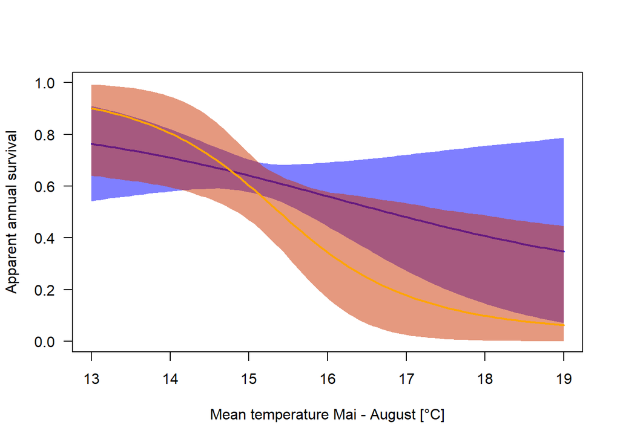

Figure 4.2: Correlation of apparent survival with summer temperature.

```r
# Trend über die Jahre

newdat <- expand.grid(temp=seq(13, 19, length=100),
                      sex=c(1,2))
newdat$temp.z <- (newdat$temp-mean(x.temp58))/sd(x.temp58)

fitmat <- matrix(NA, nrow=nrow(newdat), ncol=modtemp$n.sims)

for(r in 1:modtemp$n.sims){
  for(i in 1:nrow(newdat)){
    fitmat[i,r] <- plogis(modtemp$sims.list$b0[r,newdat$sex[i]] +
                            modtemp$sims.list$b2[r,newdat$sex[i]]*newdat$temp.z[i])
  }
}

newdat$fit <- apply(fitmat, 1, mean)
newdat$lwr <- apply(fitmat, 1, quantile, probs=0.025)
newdat$upr <- apply(fitmat, 1, quantile, probs=0.975)

plot(newdat$temp, newdat$fit, type="n", ylim=c(0,1),
     las=1, ylab="Apparent annual survival", xlab="Mean temperature Mai - August [°C]")

# M?nnchen Ambros
index <- newdat$sex==1
polygon(c(newdat$temp[index], rev(newdat$temp[index])),
        c(newdat$lwr[index], rev(newdat$upr[index])), lwd=1,
        col=rgb(0,0,1, 0.5), border=NA)

lines(newdat$temp[index], newdat$fit[index], lwd=2, col="blue")

# Weibchen Ambros
index <-  newdat$sex==2
polygon(c(newdat$temp[index], rev(newdat$temp[index])),
        c(newdat$lwr[index], rev(newdat$upr[index])), lwd=1,
        col=rgb(0.8,0.2,0, 0.5), border=NA)
lines(newdat$temp[index], newdat$fit[index], lwd=2, col="orange")
```

Correlation of winter temperature with apparent survival was weak.

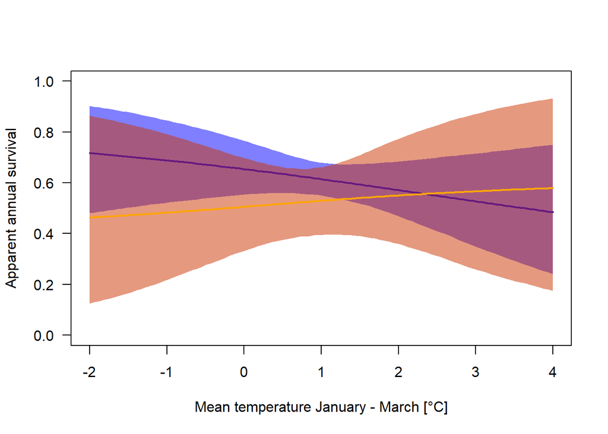

Figure 4.3: Correlation of apparent survival with winter temperature.

```r
# Trend über die Jahre

newdat <- expand.grid(temp=seq(-2, 4, length=100),
                      sex=c(1,2))
newdat$temp.z <- (newdat$temp-mean(x.temp13))/sd(x.temp13)

fitmat <- matrix(NA, nrow=nrow(newdat), ncol=modtemp$n.sims)


for(r in 1:modtemp$n.sims){
  for(i in 1:nrow(newdat)){
    fitmat[i,r] <- plogis(modtemp$sims.list$b0[r,newdat$sex[i]] +
                            modtemp$sims.list$b3[r,newdat$sex[i]]*newdat$temp.z[i])
  }
}

newdat$fit <- apply(fitmat, 1, mean)
newdat$lwr <- apply(fitmat, 1, quantile, probs=0.025)
newdat$upr <- apply(fitmat, 1, quantile, probs=0.975)

plot(newdat$temp, newdat$fit, type="n", ylim=c(0,1),
     las=1, ylab="Apparent annual survival", xlab="Mean temperature January - March [°C]")

# M?nnchen Ambros
index <- newdat$sex==1
polygon(c(newdat$temp[index], rev(newdat$temp[index])),
        c(newdat$lwr[index], rev(newdat$upr[index])), lwd=1,
        col=rgb(0,0,1, 0.5), border=NA)

lines(newdat$temp[index], newdat$fit[index], lwd=2, col="blue")

# Weibchen Ambros
index <-  newdat$sex==2
polygon(c(newdat$temp[index], rev(newdat$temp[index])),
        c(newdat$lwr[index], rev(newdat$upr[index])), lwd=1,
        col=rgb(0.8,0.2,0, 0.5), border=NA)
lines(newdat$temp[index], newdat$fit[index], lwd=2, col="orange")
```

# 5 Appendix

## 5.1 Output of model 1 with year and winter temperature as predictor

```r
print(modyear, dig=2)
```

```
## Inference for Bugs model at "jags/cjs_bugs_aichhorn_wth_temp.txt", fit using jags,
##  3 chains, each with 50000 iterations (first 25000 discarded), n.thin = 10
##  n.sims = 7500 iterations saved
##                 mean    sd    2.5%     25%     50%     75%   97.5% Rhat n.eff
## a0[1]          -3.04  0.35   -3.76   -3.27   -3.03   -2.81   -2.38 1.00  7500
## a0[2]          -3.01  0.46   -3.94   -3.31   -3.00   -2.70   -2.11 1.01   370
## b0[1]           0.63  0.17    0.33    0.51    0.62    0.73    1.02 1.01   400
## b0[2]           0.22  0.36   -0.40   -0.02    0.19    0.43    1.05 1.06    60
## b1[1]           0.09  0.15   -0.18   -0.02    0.08    0.18    0.41 1.02   130
## b1[2]          -0.24  0.23   -0.65   -0.40   -0.25   -0.10    0.27 1.03    99
## b3[1]          -0.18  0.27   -0.74   -0.37   -0.17    0.01    0.34 1.01   180
## b3[2]           0.22  0.49   -0.62   -0.10    0.17    0.48    1.44 1.06   100
## deviance     2516.80 31.27 2456.74 2495.40 2516.29 2537.85 2577.85 1.01   250
## propm[1]        0.72  0.01    0.69    0.71    0.72    0.72    0.74 1.00  7500
## propm[2]        0.28  0.01    0.26    0.28    0.28    0.29    0.31 1.00  7500
## pyeareff[1]     1.33  0.58    0.19    0.94    1.34    1.71    2.46 1.00   880
## pyeareff[2]     0.69  0.51   -0.31    0.35    0.68    1.02    1.67 1.00  6100
## pyeareff[3]    -0.43  0.65   -1.78   -0.84   -0.41    0.01    0.80 1.00  7500
## pyeareff[4]     0.80  0.57   -0.33    0.42    0.80    1.19    1.92 1.00  1400
## pyeareff[5]     0.54  0.63   -0.77    0.14    0.56    0.97    1.77 1.00  1900
## pyeareff[6]     1.63  0.61    0.45    1.22    1.62    2.04    2.86 1.00  1000
## pyeareff[7]    -0.50  0.94   -2.53   -1.08   -0.45    0.15    1.20 1.00  7500
## pyeareff[8]     3.53  0.71    2.25    3.03    3.49    3.98    5.06 1.00  1000
## pyeareff[9]     0.72  0.84   -1.00    0.17    0.76    1.31    2.29 1.00  2500
## pyeareff[10]    0.76  0.59   -0.44    0.37    0.77    1.15    1.89 1.00  7500
## pyeareff[11]   -0.78  0.90   -2.72   -1.31   -0.70   -0.16    0.77 1.00  3000
## pyeareff[12]   -1.47  1.20   -4.26   -2.15   -1.34   -0.64    0.53 1.00  3500
## pyeareff[13]   -1.25  1.29   -4.09   -2.02   -1.12   -0.34    0.90 1.00  1900
## pyeareff[14]   -1.08  1.31   -4.03   -1.86   -0.94   -0.17    1.12 1.00  2300
## pyeareff[15]    4.04  1.03    2.28    3.34    3.94    4.64    6.30 1.00  2700
## pyeareff[16]    0.11  0.77   -1.49   -0.38    0.14    0.63    1.51 1.00  2900
## pyeareff[17]    1.70  0.67    0.37    1.26    1.69    2.14    3.03 1.00  1600
## pyeareff[18]    0.21  0.60   -1.05   -0.17    0.22    0.61    1.37 1.00  7500
## pyeareff[19]   -1.76  1.16   -4.44   -2.44   -1.64   -0.96    0.17 1.00  7500
## pyeareff[20]   -1.73  1.20   -4.39   -2.42   -1.62   -0.89    0.26 1.00  7500
## pyeareff[21]   -1.56  1.23   -4.30   -2.30   -1.44   -0.71    0.52 1.00  3700
## pyeareff[22]   -0.29  0.99   -2.42   -0.91   -0.25    0.38    1.54 1.00  3800
## pyeareff[23]   -0.11  1.05   -2.35   -0.76   -0.06    0.59    1.84 1.00  4000
## pyeareff[24]   -1.08  1.34   -4.03   -1.88   -0.97   -0.14    1.23 1.00  2000
## pyeareff[25]   -0.82  1.40   -3.84   -1.66   -0.73    0.14    1.65 1.00  1500
## pyeareff[26]   -0.67  1.42   -3.67   -1.55   -0.58    0.30    1.86 1.00  3300
## pyeareff[27]   -0.53  1.52   -3.72   -1.46   -0.46    0.49    2.23 1.00  3500
## pyeareff[28]   -1.59  1.22   -4.34   -2.30   -1.47   -0.72    0.39 1.00  2900
## pyeareff[29]    0.31  0.67   -1.07   -0.12    0.34    0.77    1.56 1.00  4200
## pyeareff[30]    0.60  0.47   -0.33    0.28    0.60    0.91    1.54 1.00   800
## pyeareff[31]   -0.51  0.51   -1.56   -0.84   -0.50   -0.17    0.47 1.00  3800
## pyeareff[32]    0.60  0.42   -0.24    0.32    0.60    0.88    1.43 1.00  3400
## pyeareff[33]    0.65  0.41   -0.16    0.37    0.65    0.93    1.46 1.00   670
## pyeareff[34]   -0.25  0.51   -1.29   -0.58   -0.24    0.09    0.72 1.01   250
## pyeareff[35]   -1.78  0.85   -3.66   -2.31   -1.71   -1.20   -0.30 1.00   680
## pyeareff[36]   -2.35  1.13   -4.93   -3.00   -2.23   -1.56   -0.49 1.00   550
## pyeareff[37]   -2.06  1.23   -4.82   -2.76   -1.94   -1.18   -0.04 1.00   690
## pyeareff[38]   -1.76  1.28   -4.59   -2.51   -1.65   -0.90    0.46 1.01   340
## pyeareff[39]   -1.66  1.28   -4.52   -2.42   -1.56   -0.74    0.56 1.00   900
## sigmapyear      1.70  0.34    1.15    1.46    1.66    1.90    2.44 1.01   410
##
## For each parameter, n.eff is a crude measure of effective sample size,
## and Rhat is the potential scale reduction factor (at convergence, Rhat=1).
##
## DIC info (using the rule, pD = var(deviance)/2)
## pD = 485.2 and DIC = 3002.0
## DIC is an estimate of expected predictive error (lower deviance is better).
```

## 5.2 Output of model 2 with summer and winter temperature as predictor

```r
print(modtemp, dig=2)
```

```
## Inference for Bugs model at "jags/cjs_bugs_aichhorn_wth_year.txt", fit using jags,
##  3 chains, each with 50000 iterations (first 25000 discarded), n.thin = 10
##  n.sims = 7500 iterations saved
##                 mean    sd    2.5%     25%     50%     75%   97.5% Rhat n.eff
## a0[1]          -2.85  0.32   -3.49   -3.06   -2.84   -2.63   -2.24 1.00   690
## a0[2]          -2.83  0.42   -3.66   -3.11   -2.82   -2.55   -2.04 1.00   690
## b0[1]           0.49  0.15    0.22    0.39    0.49    0.58    0.78 1.01   670
## b0[2]           0.11  0.27   -0.44   -0.07    0.11    0.29    0.65 1.01   450
## b2[1]          -0.28  0.21   -0.69   -0.43   -0.29   -0.14    0.15 1.01   410
## b2[2]          -0.95  0.42   -1.82   -1.21   -0.94   -0.67   -0.13 1.00  1700
## b3[1]          -0.23  0.24   -0.71   -0.39   -0.23   -0.07    0.24 1.00  1300
## b3[2]           0.12  0.42   -0.73   -0.15    0.12    0.39    0.96 1.00   780
## deviance     2498.84 33.85 2433.64 2475.56 2497.82 2521.45 2565.94 1.01   300
## propm[1]        0.72  0.01    0.69    0.71    0.72    0.72    0.74 1.00  7500
## propm[2]        0.28  0.01    0.26    0.28    0.28    0.29    0.31 1.00  7500
## pyeareff[1]     1.04  0.54   -0.05    0.68    1.04    1.40    2.08 1.00  2400
## pyeareff[2]     0.49  0.47   -0.46    0.18    0.50    0.81    1.38 1.00  2200
## pyeareff[3]    -0.47  0.60   -1.72   -0.85   -0.44   -0.06    0.64 1.00  1600
## pyeareff[4]     0.58  0.52   -0.47    0.23    0.58    0.93    1.58 1.00  6900
## pyeareff[5]     0.31  0.58   -0.87   -0.07    0.33    0.71    1.44 1.00  7500
## pyeareff[6]     1.28  0.55    0.18    0.91    1.27    1.65    2.37 1.00  7500
## pyeareff[7]    -0.55  0.85   -2.39   -1.07   -0.48    0.04    0.95 1.00  7500
## pyeareff[8]     3.20  0.64    2.05    2.75    3.17    3.60    4.55 1.00  7500
## pyeareff[9]     0.56  0.78   -1.04    0.06    0.59    1.10    2.01 1.00  2700
## pyeareff[10]    0.50  0.56   -0.62    0.14    0.51    0.89    1.58 1.00  7500
## pyeareff[11]   -0.86  0.82   -2.61   -1.35   -0.80   -0.30    0.59 1.00  4400
## pyeareff[12]   -1.35  1.04   -3.65   -1.96   -1.25   -0.63    0.40 1.00  7500
## pyeareff[13]   -1.14  1.10   -3.55   -1.81   -1.04   -0.37    0.71 1.00  7500
## pyeareff[14]   -1.03  1.11   -3.40   -1.71   -0.94   -0.25    0.85 1.00  3300
## pyeareff[15]    3.16  0.95    1.55    2.51    3.06    3.73    5.29 1.00  1700
## pyeareff[16]   -0.26  0.71   -1.79   -0.70   -0.22    0.21    1.05 1.00  7500
## pyeareff[17]    1.15  0.63   -0.07    0.73    1.16    1.57    2.38 1.00  7500
## pyeareff[18]    0.16  0.58   -1.03   -0.23    0.17    0.55    1.25 1.00  3300
## pyeareff[19]   -1.43  1.06   -3.82   -2.02   -1.34   -0.68    0.34 1.00  7500
## pyeareff[20]   -1.52  1.01   -3.81   -2.13   -1.43   -0.81    0.21 1.00  7500
## pyeareff[21]   -1.36  1.06   -3.77   -1.99   -1.26   -0.63    0.43 1.00  7500
## pyeareff[22]   -0.24  0.89   -2.10   -0.81   -0.21    0.36    1.42 1.00  3200
## pyeareff[23]   -0.14  0.93   -2.09   -0.72   -0.10    0.50    1.57 1.00  4100
## pyeareff[24]   -0.82  1.15   -3.28   -1.52   -0.75   -0.05    1.25 1.00  7300
## pyeareff[25]   -0.58  1.25   -3.29   -1.33   -0.51    0.26    1.71 1.00  7500
## pyeareff[26]   -0.41  1.27   -3.06   -1.20   -0.34    0.44    1.93 1.00  7500
## pyeareff[27]   -0.30  1.33   -3.04   -1.12   -0.28    0.56    2.20 1.00  7500
## pyeareff[28]   -1.27  1.06   -3.58   -1.90   -1.16   -0.52    0.52 1.00  7500
## pyeareff[29]    0.35  0.66   -1.00   -0.05    0.37    0.80    1.58 1.00  2300
## pyeareff[30]    0.87  0.49   -0.11    0.55    0.87    1.20    1.83 1.00   830
## pyeareff[31]   -0.53  0.48   -1.48   -0.85   -0.52   -0.20    0.38 1.00  7500
## pyeareff[32]    0.47  0.39   -0.30    0.21    0.47    0.74    1.25 1.00  1700
## pyeareff[33]    0.69  0.39   -0.09    0.44    0.69    0.94    1.45 1.00   980
## pyeareff[34]    0.12  0.53   -0.93   -0.23    0.13    0.48    1.13 1.00   550
## pyeareff[35]   -1.39  0.79   -3.14   -1.87   -1.33   -0.84   -0.02 1.00  2100
## pyeareff[36]   -1.72  1.04   -4.07   -2.34   -1.61   -1.01    0.02 1.00  6600
## pyeareff[37]   -1.28  1.10   -3.63   -1.96   -1.19   -0.53    0.68 1.00  2000
## pyeareff[38]   -0.94  1.21   -3.54   -1.69   -0.87   -0.12    1.25 1.00  5000
## pyeareff[39]   -0.75  1.26   -3.51   -1.52   -0.68    0.09    1.50 1.00  7500
## sigmapyear      1.43  0.30    0.93    1.22    1.40    1.60    2.08 1.00  7500
##
## For each parameter, n.eff is a crude measure of effective sample size,
## and Rhat is the potential scale reduction factor (at convergence, Rhat=1).
##
## DIC info (using the rule, pD = var(deviance)/2)
## pD = 569.3 and DIC = 3068.2
## DIC is an estimate of expected predictive error (lower deviance is better).
```

Kemp, Michael U, E Emiel van Loon, Judy Shamoun-Baranes, and Willem Bouten. 2012. “RNCEP: Global Weather and Climate Data at Your Fingertips.” *Methods in Ecology and Evolution* 3: 65–70.